# MEM-Analysis

```python
# the usual suspects...
# import sys                             # system module , don't usually need
import numpy as np                  # pandas uses numpy, and sometimes want to use numpy within pandas
import pandas as pd # data package, redundant since already did # graphics package

import matplotlib.pyplot as plt      # graphics package
import seaborn as sns               # makes matplotlib prettier without issuing a single command!
import datetime as dt                  # date and time module, sometimes need to use


%matplotlib inline
print(plt.style.available)
plt.style.use('ggplot')
```

```
['seaborn-dark', 'seaborn-darkgrid', 'seaborn-ticks', 'fivethirtyeight', 'seaborn-whitegrid', 'classic', '_classic_test', 'fast', 'seaborn-talk', 'seaborn-dark-palette', 'seaborn-bright', 'seaborn-pastel', 'grayscale', 'seaborn-notebook', 'ggplot', 'seaborn-colorblind', 'seaborn-muted', 'seaborn', '…
```

```python
# read in MSA csv
MSA='McAllen-Edinburgh-Mission'
ddf=pd.read_csv(MSA+'.csv')

print(ddf.shape)
ddf.dtypes
```

```
(70464, 27)
```

```
Unnamed: 0       int64
hocono           int64
hoco            object
state           object
blockcode        int64
tech            object
unq_fcctk17    float64
sumc17         float64
cmaxd17        float64
cmaxu17        float64
sumb17         float64
bmaxd17        float64
bmaxu17        float64
unq_fcctk14    float64
sumc14         float64
cmaxd14        float64
cmaxu14        float64
sumb14         float64
bmaxd14        float64
bmaxu14        float64
pop10          float64
hu10           float64
land10         float64
msa             object
ur              object
county         float64
cty_name        object
dtype: object
```

```python
ddf=ddf.iloc[:,1:] # drop unneeded 1st column
print(ddf.shape)
ddf.loc[(ddf.pop10>0)&(ddf.hu10>0),'has_phu10']=1 # new column =1 for blocks with people and hu's in 2010
# pandas default creating new column using .loc,assignment w/ logical condition on rows:
# assigns NaN when not explicitly assigned, so change this to zero
ddf.loc[(ddf['has_phu10'].isna()),'has_phu10']=0
print(ddf.shape)
print(ddf.dtypes)
ddf.describe()
```

```
(70464, 26)
(70464, 27)
hocono           int64
hoco            object
state           object
blockcode        int64
tech            object
unq_fcctk17    float64
sumc17         float64
cmaxd17        float64
cmaxu17        float64
sumb17         float64
bmaxd17        float64
bmaxu17        float64
unq_fcctk14    float64
sumc14         float64
cmaxd14        float64
cmaxu14        float64
sumb14         float64
bmaxd14        float64
bmaxu14        float64
pop10          float64
hu10           float64
land10         float64
msa             object
ur              object
county         float64
cty_name        object
has_phu10      float64
dtype: object
```

|  | hocono | blockcode | unq_fcctk17 | sumc17 | cmaxd17 | cmaxu17 | sumb17 | bmaxd17 | bmaxu17 | unq_fcctk14 | ... | cmaxd14 | cmaxu14 | sumb14 | bmaxd14 | bmaxu14 | pop10 | hu10 | land10 | county | has_phu10 |
| --- | --- | --- | --- | --- | --- | --- | --- | --- | --- | --- | --- | --- | --- | --- | --- | --- | --- | --- | --- | --- | --- |
| count | 70464.000000 | 7.046400e+04 | 50052.000000 | 50052.000000 | 50052.000000 | 50052.000000 | 50052.000000 | 50052.000000 | 50052.000000 | 25779.000000 | ... | 25779.000000 | 25779.000000 | 25779.000000 | 25779.000000 | 25779.000000 | 70464.000000 | 70464.000000 | 7.046400e+04 | 70464.0 | 70464.000000 |
| mean | 224675.432760 | 4.821502e+14 | 1.109027 | 1.122133 | 68.518387 | 22.326650 | 0.606889 | 20.789781 | 20.698416 | 1.000116 | ... | 17.145400 | 3.562692 | 0.747197 | 0.875286 | 0.845611 | 77.566332 | 24.948882 | 1.588244e+05 | 48215.0 | 0.998524 |
| std | 95333.704112 | 1.348281e+07 | 0.345599 | 0.373772 | 62.953396 | 54.663804 | 0.524540 | 43.447390 | 43.445183 | 0.010787 | ... | 30.161075 | 28.522328 | 0.451697 | 28.666540 | 28.545438 | 122.910428 | 39.230093 | 9.285317e+05 | 0.0 | 0.038390 |
| min | 130077.000000 | 4.821502e+14 | 1.000000 | 1.000000 | 0.256000 | 0.128000 | 0.000000 | 0.000000 | 0.000000 | 1.000000 | ... | 0.768000 | 0.000000 | 0.000000 | 0.000000 | 0.000000 | 1.000000 | 0.000000 | 5.800000e+01 | 48215.0 | 0.000000 |
| 25% | 131352.000000 | 4.821502e+14 | 1.000000 | 1.000000 | 30.000000 | 5.000000 | 0.000000 | 0.000000 | 0.000000 | 1.000000 | ... | 10.000000 | 1.500000 | 0.000000 | 0.000000 | 0.000000 | 20.000000 | 8.000000 | 1.219000e+04 | 48215.0 | 1.000000 |
| 50% | 131411.000000 | 4.821502e+14 | 1.000000 | 1.000000 | 40.000000 | 10.000000 | 1.000000 | 0.000000 | 0.000000 | 1.000000 | ... | 10.000000 | 2.000000 | 1.000000 | 0.000000 | 0.000000 | 44.000000 | 15.000000 | 2.126600e+04 | 48215.0 | 1.000000 |
| 75% | 320091.000000 | 4.821502e+14 | 1.000000 | 1.000000 | 98.000000 | 51.000000 | 1.000000 | 0.000000 | 0.000000 | 1.000000 | ... | 30.000000 | 5.000000 | 1.000000 | 0.000000 | 0.000000 | 84.000000 | 26.000000 | 6.048600e+04 | 48215.0 | 1.000000 |
| max | 370161.000000 | 4.821502e+14 | 3.000000 | 4.000000 | 1000.000000 | 1000.000000 | 4.000000 | 1000.000000 | 1000.000000 | 2.000000 | ... | 1000.000000 | 1000.000000 | 2.000000 | 1000.000000 | 1000.000000 | 2512.000000 | 990.000000 | 1.060967e+08 | 48215.0 | 1.000000 |

8 rows × 21 columns

##### Recode consumer service count dummies to 1 if >1

```python
ddf.fillna(value=0,inplace=True) # change missing to zero
ddf.loc[(ddf['sumc14']>0),'sumc14']=1
# number of original FCC tech codes in Flamm tech code still found in unq_fcctk14
# change sumcxx into binary (0,1) service indicator hoco/tech combo instead
ddf.loc[(ddf['sumc17']>0),'sumc17']=1  #number of FCC tech codes used within Flamm tech code still unq_fcctk17
ddf.describe()
```

|  | hocono | blockcode | unq_fcctk17 | sumc17 | cmaxd17 | cmaxu17 | sumb17 | bmaxd17 | bmaxu17 | unq_fcctk14 | ... | cmaxd14 | cmaxu14 | sumb14 | bmaxd14 | bmaxu14 | pop10 | hu10 | land10 | county | has_phu10 |
| --- | --- | --- | --- | --- | --- | --- | --- | --- | --- | --- | --- | --- | --- | --- | --- | --- | --- | --- | --- | --- | --- |
| count | 70464.000000 | 7.046400e+04 | 70464.000000 | 70464.000000 | 70464.000000 | 70464.000000 | 70464.000000 | 70464.000000 | 70464.000000 | 70464.000000 | ... | 70464.000000 | 70464.000000 | 70464.000000 | 70464.000000 | 70464.000000 | 70464.000000 | 70464.000000 | 7.046400e+04 | 70464.0 | 70464.000000 |
| mean | 224675.432760 | 4.821502e+14 | 0.787764 | 0.710320 | 48.669992 | 15.859070 | 0.431085 | 14.767401 | 14.702502 | 0.365889 | ... | 6.272583 | 1.303398 | 0.273359 | 0.320220 | 0.309364 | 77.566332 | 24.948882 | 1.588244e+05 | 48215.0 | 0.998524 |
| std | 95333.704112 | 1.348281e+07 | 0.581311 | 0.453617 | 61.490730 | 47.170849 | 0.520793 | 37.812465 | 37.800348 | 0.481770 | ... | 20.024994 | 17.336724 | 0.451854 | 17.343937 | 17.270367 | 122.910428 | 39.230093 | 9.285317e+05 | 0.0 | 0.038390 |
| min | 130077.000000 | 4.821502e+14 | 0.000000 | 0.000000 | 0.000000 | 0.000000 | 0.000000 | 0.000000 | 0.000000 | 0.000000 | ... | 0.000000 | 0.000000 | 0.000000 | 0.000000 | 0.000000 | 1.000000 | 0.000000 | 5.800000e+01 | 48215.0 | 0.000000 |
| 25% | 131352.000000 | 4.821502e+14 | 0.000000 | 0.000000 | 0.000000 | 0.000000 | 0.000000 | 0.000000 | 0.000000 | 0.000000 | ... | 0.000000 | 0.000000 | 0.000000 | 0.000000 | 0.000000 | 20.000000 | 8.000000 | 1.219000e+04 | 48215.0 | 1.000000 |
| 50% | 131411.000000 | 4.821502e+14 | 1.000000 | 1.000000 | 30.000000 | 5.000000 | 0.000000 | 0.000000 | 0.000000 | 0.000000 | ... | 0.000000 | 0.000000 | 0.000000 | 0.000000 | 0.000000 | 44.000000 | 15.000000 | 2.126600e+04 | 48215.0 | 1.000000 |
| 75% | 320091.000000 | 4.821502e+14 | 1.000000 | 1.000000 | 98.000000 | 10.000000 | 1.000000 | 0.000000 | 0.000000 | 1.000000 | ... | 10.000000 | 2.000000 | 1.000000 | 0.000000 | 0.000000 | 84.000000 | 26.000000 | 6.048600e+04 | 48215.0 | 1.000000 |
| max | 370161.000000 | 4.821502e+14 | 3.000000 | 1.000000 | 1000.000000 | 1000.000000 | 4.000000 | 1000.000000 | 1000.000000 | 2.000000 | ... | 1000.000000 | 1000.000000 | 2.000000 | 1000.000000 | 1000.000000 | 2512.000000 | 990.000000 | 1.060967e+08 | 48215.0 | 1.000000 |

8 rows × 21 columns

```python
pd.options.display.max_rows=75

print('hoco/tech block counts, 2017','\n')
print(ddf.groupby(['hoco']).sumc17.sum())
```

```
hoco/tech block counts, 2017

hoco
AT&T Inc.                                     6042.0
Aerolink Networks                               59.0
Aeronet Wireless Broadband LLC                   1.0
Central Texas Telephone Cooperative, Inc.        0.0
CenturyLink, Inc.                                0.0
Charter Communications                        8876.0
Comcast Corporation                              4.0
En-Touch Systems, Inc.                           4.0
Smartcom Telephone, LLC                        220.0
Smith Internet Solutions                        53.0
Tabco Services                               14174.0
Time Warner Cable Inc.                           0.0
Valley Telephone Cooperative, Inc.               0.0
Valley Telephone Cooperative, Inc. (TX)      10324.0
WIFIRUS                                          6.0
Windstream Holdings, Inc.                        3.0
Wireless Internet Corp.                      10286.0
Wireless Internet Corporation                    0.0
Name: sumc17, dtype: float64
```

#### Overview

##### First, some useful summary info

```python
# first, get some useful summary info
# display number of hocos using Flamm tech mode in any block of MSA, by tech
print('numbers of hocos using tech anywhere in MSA, any year, for different bb techs')
print(pd.pivot_table(ddf.loc[(ddf.has_phu10>0)],index=['tech'],aggfunc={'hoco':'nunique'}),'\n')
print('\n','number census blocks ever served with :')
print(pd.pivot_table(ddf.loc[(ddf.has_phu10>0)],index=['tech'],aggfunc={'blockcode':'nunique'}),'\n')

print('\n','number rural/urban census blocks ever served with (any year):')
print(pd.pivot_table(ddf.loc[(ddf.has_phu10>0)],index=['tech','ur'],aggfunc={'blockcode':'nunique'}),'\n')
# Another way to do the exact same thing:
ddf.loc[(ddf.has_phu10>0)].groupby(by=['tech','ur']).blockcode.nunique()
```

```
numbers of hocos using tech anywhere in MSA, any year, for different bb techs
         hoco
tech
cable       5
dsl         6
fiber       5
fxdwlss    11
oth_cu      1


 number census blocks ever served with :
         blockcode
tech
cable         9531
dsl           7534
fiber          242
fxdwlss      10295
oth_cu          71


 number rural/urban census blocks ever served with (any year):
            blockcode
tech    ur
cable   R         473
        U        9058
dsl     R         474
        U        7060
fiber   R         135
        U         107
fxdwlss R         950
        U        9345
oth_cu  R          12
        U          59
```

```
tech     ur
cable    R      473
         U     9058
dsl      R      474
         U     7060
fiber    R      135
         U      107
fxdwlss  R      950
         U     9345
oth_cu   R       12
         U       59
Name: blockcode, dtype: int64
```

##### Drop census blocks without population or housing

```python
ddf=ddf.loc[(ddf.has_phu10>0)]
```

## 1 and 2A. construct market shares by hoco (share of total msa blocks served):

##### Add tech dummies to dataframe

```python
# add block-level tech dummies to dataframe: =0 if not tech, =1 if tech used in hoco/tech combo
# for future use...
dummies=pd.get_dummies(ddf.tech,prefix='tech')
ddf=pd.concat([ddf,dummies],axis=1)
ddf.describe()
```

|  | hocono | blockcode | unq_fcctk17 | sumc17 | cmaxd17 | cmaxu17 | sumb17 | bmaxd17 | bmaxu17 | unq_fcctk14 | ... | pop10 | hu10 | land10 | county | has_phu10 | tech_cable | tech_dsl | tech_fiber | tech_fxdwlss | tech_oth_cu |
| --- | --- | --- | --- | --- | --- | --- | --- | --- | --- | --- | --- | --- | --- | --- | --- | --- | --- | --- | --- | --- | --- |
| count | 70360.000000 | 7.036000e+04 | 70360.000000 | 70360.000000 | 70360.000000 | 70360.000000 | 70360.000000 | 70360.000000 | 70360.000000 | 70360.000000 | ... | 70360.000000 | 70360.000000 | 7.036000e+04 | 70360.0 | 70360.0 | 70360.000000 | 70360.000000 | 70360.000000 | 70360.000000 | 70360.000000 |
| mean | 224682.634949 | 4.821502e+14 | 0.787777 | 0.710347 | 48.672659 | 15.862200 | 0.431069 | 14.767483 | 14.702489 | 0.365861 | ... | 77.468775 | 24.985759 | 1.588720e+05 | 48215.0 | 1.0 | 0.353127 | 0.108954 | 0.004491 | 0.532419 | 0.001009 |
| std | 95334.219535 | 1.348064e+07 | 0.581277 | 0.453605 | 61.511412 | 47.200079 | 0.520746 | 37.816281 | 37.804147 | 0.481763 | ... | 122.149282 | 39.247339 | 9.291940e+05 | 0.0 | 0.0 | 0.477945 | 0.311584 | 0.066866 | 0.498951 | 0.031750 |
| min | 130077.000000 | 4.821502e+14 | 0.000000 | 0.000000 | 0.000000 | 0.000000 | 0.000000 | 0.000000 | 0.000000 | 0.000000 | ... | 1.000000 | 1.000000 | 5.800000e+01 | 48215.0 | 1.0 | 0.000000 | 0.000000 | 0.000000 | 0.000000 | 0.000000 |
| 25% | 131352.000000 | 4.821502e+14 | 0.000000 | 0.000000 | 0.000000 | 0.000000 | 0.000000 | 0.000000 | 0.000000 | 0.000000 | ... | 20.000000 | 8.000000 | 1.219000e+04 | 48215.0 | 1.0 | 0.000000 | 0.000000 | 0.000000 | 0.000000 | 0.000000 |
| 50% | 131411.000000 | 4.821502e+14 | 1.000000 | 1.000000 | 30.000000 | 5.000000 | 0.000000 | 0.000000 | 0.000000 | 0.000000 | ... | 44.000000 | 15.000000 | 2.124200e+04 | 48215.0 | 1.0 | 0.000000 | 0.000000 | 0.000000 | 1.000000 | 0.000000 |
| 75% | 320091.000000 | 4.821502e+14 | 1.000000 | 1.000000 | 98.000000 | 10.000000 | 1.000000 | 0.000000 | 0.000000 | 1.000000 | ... | 84.000000 | 26.000000 | 6.040600e+04 | 48215.0 | 1.0 | 1.000000 | 0.000000 | 0.000000 | 1.000000 | 0.000000 |
| max | 370161.000000 | 4.821502e+14 | 3.000000 | 1.000000 | 1000.000000 | 1000.000000 | 4.000000 | 1000.000000 | 1000.000000 | 2.000000 | ... | 2199.000000 | 990.000000 | 1.060967e+08 | 48215.0 | 1.0 | 1.000000 | 1.000000 | 1.000000 | 1.000000 | 1.000000 |

8 rows × 26 columns

```python
ddf.dtypes
```

```
hocono            int64
hoco             object
state            object
blockcode         int64
tech             object
unq_fcctk17     float64
sumc17          float64
cmaxd17         float64
cmaxu17         float64
sumb17          float64
bmaxd17         float64
bmaxu17         float64
unq_fcctk14     float64
sumc14          float64
cmaxd14         float64
cmaxu14         float64
sumb14          float64
bmaxd14         float64
bmaxu14         float64
pop10           float64
hu10            float64
land10          float64
msa              object
ur               object
county          float64
cty_name         object
has_phu10       float64
tech_cable        uint8
tech_dsl          uint8
tech_fiber        uint8
tech_fxdwlss      uint8
tech_oth_cu       uint8
dtype: object
```

```python
# prelim step to create one hoco record per blockcode
# want number of providers providing service, and using tech, by blockcode
# note that sum by tech per block will add up to more than number isps per block if more than one tech per isp

techlist=['cable','dsl','fiber','fxdwlss','oth_cu']
#*********** IMPORTANT *********   make sure list of techs in line above matches list of techs present in your MSA

tech14list=[techlist[i]+'14' for i in range(0,len(techlist))] # good application for a list comprehension
tech17list=[techlist[i]+'17' for i in range(0,len(techlist))]

# create variable with value =1 if tech used in that year by hoco in census block
for i in range(0,len(techlist)):
    ddf.loc[:,tech14list[i]]=ddf.sumc14.astype(int)*ddf['tech_'+techlist[i]]
    ddf.loc[:,tech17list[i]]=ddf.sumc17.astype(int)*ddf['tech_'+techlist[i]]
ddf.dtypes
```

```
hocono            int64
hoco             object
state            object
blockcode         int64
tech             object
unq_fcctk17     float64
sumc17          float64
cmaxd17         float64
cmaxu17         float64
sumb17          float64
bmaxd17         float64
bmaxu17         float64
unq_fcctk14     float64
sumc14          float64
cmaxd14         float64
cmaxu14         float64
sumb14          float64
bmaxd14         float64
bmaxu14         float64
pop10           float64
hu10            float64
land10          float64
msa              object
ur               object
county          float64
cty_name         object
has_phu10       float64
tech_cable        uint8
tech_dsl          uint8
tech_fiber        uint8
tech_fxdwlss      uint8
tech_oth_cu       uint8
cable14           int64
cable17           int64
dsl14             int64
dsl17             int64
fiber14           int64
fiber17           int64
fxdwlss14         int64
fxdwlss17         int64
oth_cu14          int64
oth_cu17          int64
dtype: object
```

```python
# ddf still has one line per tech/hoco combo per census block
# every blockcode has sumc14 Flamm-coded tech/hoco providers in 2014,same for 2017 after executing above
#
# create dummy variable for urban
ddf.loc[:,'u_dum']=0
ddf.loc[(ddf.ur=='U'),'u_dum']=1
# NOW, create single summary record per blockcode
# outhoco will have one line per hoco per blockcode, sumc1x > 0 if ISP provides consumer service to that block
#

techdict={'sumc14':'sum','sumc17':'sum','cable14':'sum','dsl14':'sum','fiber14':'sum',
          'fxdwlss14':'sum','oth_cu14':'sum',
         'cable17':'sum','dsl17':'sum','fiber17':'sum',
          'fxdwlss17':'sum','oth_cu17':'sum','cmaxd14':'max','cmaxu14':'max',
          'cmaxd17':'max','cmaxu17':'max','u_dum':'max','pop10':'mean','hu10':'mean','land10':'mean'}
# sumcxx variables are # techs used in block by hoco, techxx variables are 0, 1 for tech used by hoco in block
# cmaxdxx variables are max speed in block across all hoco techs
outhoco=ddf.groupby(by=['blockcode','hoco'],as_index=False).agg(
    techdict)

# ddf has one line per tech/hoco combo per census block
# every blockcode has sumc14 Flamm-coded tech/hoco providers in 2014,same for 2017 after executing above
#
# outhoco has one line per blockcode, per hoco, sumc1x > 0 if hoco provides consumer service to that block
# value of sumc1x is number of techs used, should equal sum of 'tech'_1x dummies
# upload and download speed for block and hoco is max across technologies and year

# check for errors:
outhoco.loc[:,'check14']=(outhoco.sumc14-outhoco.cable14-outhoco.dsl14-outhoco.fiber14-outhoco.fxdwlss14-
                          outhoco.oth_cu14)
outhoco.loc[:,'check17']=(outhoco.sumc17-outhoco.cable17-outhoco.dsl17-outhoco.fiber17-outhoco.fxdwlss17-
                          outhoco.oth_cu17)
print(pd.crosstab(outhoco.check14,outhoco.check17))
outhoco.describe()
```

```
check17    0.0
check14
0.0      63201
```

|  | blockcode | sumc14 | sumc17 | cable14 | dsl14 | fiber14 | fxdwlss14 | oth_cu14 | cable17 | dsl17 | ... | cmaxd14 | cmaxu14 | cmaxd17 | cmaxu17 | u_dum | pop10 | hu10 | land10 | check14 | check17 |
| --- | --- | --- | --- | --- | --- | --- | --- | --- | --- | --- | --- | --- | --- | --- | --- | --- | --- | --- | --- | --- | --- |
| count | 6.320100e+04 | 63201.000000 | 63201.000000 | 63201.000000 | 63201.000000 | 63201.000000 | 63201.000000 | 63201.000000 | 63201.00000 | 63201.000000 | ... | 63201.000000 | 63201.000000 | 63201.000000 | 63201.000000 | 63201.000000 | 63201.000000 | 63201.000000 | 6.320100e+04 | 63201.0 | 63201.0 |
| mean | 4.821502e+14 | 0.407256 | 0.790810 | 0.140868 | 0.108036 | 0.001851 | 0.155583 | 0.000918 | 0.25229 | 0.097166 | ... | 6.978275 | 1.449755 | 43.196778 | 11.945417 | 0.934969 | 77.298761 | 24.914827 | 1.578176e+05 | 0.0 | 0.0 |
| std | 1.364345e+07 | 0.492228 | 0.625402 | 0.347888 | 0.310429 | 0.042986 | 0.362462 | 0.030280 | 0.43433 | 0.296186 | ... | 21.013438 | 18.298722 | 62.510132 | 48.232262 | 0.246582 | 121.483202 | 39.015401 | 9.448951e+05 | 0.0 | 0.0 |
| min | 4.821502e+14 | 0.000000 | 0.000000 | 0.000000 | 0.000000 | 0.000000 | 0.000000 | 0.000000 | 0.00000 | 0.000000 | ... | 0.000000 | 0.000000 | 0.000000 | 0.000000 | 0.000000 | 1.000000 | 1.000000 | 5.800000e+01 | 0.0 | 0.0 |
| 25% | 4.821502e+14 | 0.000000 | 0.000000 | 0.000000 | 0.000000 | 0.000000 | 0.000000 | 0.000000 | 0.00000 | 0.000000 | ... | 0.000000 | 0.000000 | 0.000000 | 0.000000 | 1.000000 | 20.000000 | 8.000000 | 1.219800e+04 | 0.0 | 0.0 |
| 50% | 4.821502e+14 | 0.000000 | 1.000000 | 0.000000 | 0.000000 | 0.000000 | 0.000000 | 0.000000 | 0.00000 | 0.000000 | ... | 0.000000 | 0.000000 | 30.000000 | 5.000000 | 1.000000 | 44.000000 | 15.000000 | 2.121000e+04 | 0.0 | 0.0 |
| 75% | 4.821502e+14 | 1.000000 | 1.000000 | 0.000000 | 0.000000 | 0.000000 | 0.000000 | 0.000000 | 1.00000 | 0.000000 | ... | 10.000000 | 2.000000 | 98.000000 | 10.000000 | 1.000000 | 84.000000 | 26.000000 | 5.988200e+04 | 0.0 | 0.0 |
| max | 4.821502e+14 | 3.000000 | 2.000000 | 1.000000 | 1.000000 | 1.000000 | 1.000000 | 1.000000 | 1.00000 | 1.000000 | ... | 1000.000000 | 1000.000000 | 1000.000000 | 1000.000000 | 1.000000 | 2199.000000 | 990.000000 | 1.060967e+08 | 0.0 | 0.0 |

8 rows × 23 columns

##### everything adds up like it should, that's a good sign...

Now recode sumcxx to binary (0,1) indicator if block served, replacing number techs used by hoco to serve block

```python
# outhoco has 1 line per hoco per block ever served by that hoco
# convert sumcxx = # hoco-tech combos service per block into single binary indicator of any service at all
outhoco.loc[(outhoco['sumc14']>0),'sumc14']=1
# overwrite sumc14 with binary indicator variable for block has at least one 2014 hoco-tech service
outhoco.loc[(outhoco['sumc17']>0),'sumc17']=1
print('\n','hoco-tech combos of consumer service provided by census block:','\n')
print(outhoco.describe())
print('\n','Note: hoco counted multiple times if serves block with multiple techs.')
```

```
 hoco-tech combos of consumer service provided by census block:

          blockcode        sumc14        sumc17       cable14         dsl14  \
count  6.320100e+04  63201.000000  63201.000000  63201.000000  63201.000000
mean   4.821502e+14      0.406845      0.677964      0.140868      0.108036
std    1.364345e+07      0.491249      0.467260      0.347888      0.310429
min    4.821502e+14      0.000000      0.000000      0.000000      0.000000
25%    4.821502e+14      0.000000      0.000000      0.000000      0.000000
50%    4.821502e+14      0.000000      1.000000      0.000000      0.000000
75%    4.821502e+14      1.000000      1.000000      0.000000      0.000000
max    4.821502e+14      1.000000      1.000000      1.000000      1.000000

            fiber14     fxdwlss14      oth_cu14      cable17         dsl17  \
count  63201.000000  63201.000000  63201.000000  63201.00000  63201.000000
mean       0.001851      0.155583      0.000918      0.25229      0.097166
std        0.042986      0.362462      0.030280      0.43433      0.296186
min        0.000000      0.000000      0.000000      0.00000      0.000000
25%        0.000000      0.000000      0.000000      0.00000      0.000000
50%        0.000000      0.000000      0.000000      0.00000      0.000000
75%        0.000000      0.000000      0.000000      1.00000      0.000000
max        1.000000      1.000000      1.000000      1.00000      1.000000

        ...          cmaxd14       cmaxu14       cmaxd17       cmaxu17  \
count   ...     63201.000000  63201.000000  63201.000000  63201.000000
mean    ...         6.978275      1.449755     43.196778     11.945417
std     ...        21.013438     18.298722     62.510132     48.232262
min     ...         0.000000      0.000000      0.000000      0.000000
25%     ...         0.000000      0.000000      0.000000      0.000000
50%     ...         0.000000      0.000000     30.000000      5.000000
75%     ...        10.000000      2.000000     98.000000     10.000000
max     ...      1000.000000   1000.000000   1000.000000   1000.000000

              u_dum         pop10          hu10        land10  check14  \
count  63201.000000  63201.000000  63201.000000  6.320100e+04  63201.0
mean       0.934969     77.298761     24.914827  1.578176e+05      0.0
std        0.246582    121.483202     39.015401  9.448951e+05      0.0
min        0.000000      1.000000      1.000000  5.800000e+01      0.0
25%        1.000000     20.000000      8.000000  1.219800e+04      0.0
50%        1.000000     44.000000     15.000000  2.121000e+04      0.0
75%        1.000000     84.000000     26.000000  5.988200e+04      0.0
max        1.000000   2199.000000    990.000000  1.060967e+08      0.0

       check17
count  63201.0
mean       0.0
std        0.0
min        0.0
25%        0.0
50%        0.0
75%        0.0
max        0.0

[8 rows x 23 columns]

 Note: hoco counted multiple times if serves block with multiple techs.
```

##### Now create single record per block, sumcxx is number of hocos serving block, 'tech'xx number of hocos using tech 'xx' to serve block, cmaxdxx is max download speed offered from any provider

```python
outsum=outhoco.groupby(by=['blockcode'],as_index=False).agg(
    techdict) # 1 line per block in this dataframe
# sumcxx is now number of hocos serving block, cmaxdxx is max speed across both hocos and tech
# 'tech'xx is number of hocos using 'tech' in block
outsum['D_msa']=1
# dummy variable indicator set = 1 in every block in sample regardless of being served status,
# needed to count blocks
outcomp=outsum.copy()
all_blocks = outsum.D_msa.cumsum().iloc[-1]  # total number blocks w/2010 pop & hu in Dallas MSA
outsum.loc[(outsum.sumc14>0),'sumc14']=1 # recode sumc14/17 to binary dummy variable for served block counts
outsum.loc[(outsum.sumc17>0),'sumc17']=1
tot_blocks14=outsum.sumc14.cumsum().iloc[-1] #add up number of subset served blocks in 2014
tot_blocks17=outsum.sumc17.cumsum().iloc[-1] # same for 2017

#### now recode tech variables to binary (0,1)/total number served blocks
for j in range(0,len(techlist)):
    outsum.loc[(outsum[tech14list[j]]>0),tech14list[j]]=1
    outsum.loc[(outsum[tech17list[j]]>0),tech17list[j]]=1
# outsum has single line per block

print('total number served populated blocks with hu in DFW msa, 14 and 17 =',tot_blocks14,tot_blocks17)
print('total number populated blocks with hu 2010 in DFW msa',all_blocks)
# outsum.describe() means should be shares of blocks with service overall and by tech availability
outsum.describe()
```

```
total number served populated blocks with hu in DFW msa, 14 and 17 = 10279.0 10421.0
total number populated blocks with hu 2010 in DFW msa 10427
```

|  | blockcode | sumc14 | sumc17 | cable14 | dsl14 | fiber14 | fxdwlss14 | oth_cu14 | cable17 | dsl17 | ... | oth_cu17 | cmaxd14 | cmaxu14 | cmaxd17 | cmaxu17 | u_dum | pop10 | hu10 | land10 | D_msa |
| --- | --- | --- | --- | --- | --- | --- | --- | --- | --- | --- | --- | --- | --- | --- | --- | --- | --- | --- | --- | --- | --- |
| count | 1.042700e+04 | 10427.000000 | 10427.000000 | 10427.000000 | 10427.000000 | 10427.000000 | 10427.000000 | 10427.000000 | 10427.000000 | 10427.000000 | ... | 10427.000000 | 10427.000000 | 10427.000000 | 10427.000000 | 10427.000000 | 10427.000000 | 10427.000000 | 10427.000000 | 1.042700e+04 | 10427.0 |
| mean | 4.821502e+14 | 0.985806 | 0.999425 | 0.853649 | 0.649372 | 0.011125 | 0.940251 | 0.005562 | 0.912918 | 0.583965 | ... | 0.002685 | 29.236845 | 6.611229 | 124.077649 | 50.906425 | 0.901889 | 73.882229 | 23.711614 | 2.169905e+05 | 1.0 |
| std | 1.393706e+07 | 0.118295 | 0.023982 | 0.353475 | 0.477190 | 0.104892 | 0.237032 | 0.074378 | 0.281968 | 0.492923 | ... | 0.051753 | 44.298293 | 44.660453 | 103.735065 | 110.341827 | 0.297478 | 116.804053 | 37.264925 | 1.504313e+06 | 0.0 |
| min | 4.821502e+14 | 0.000000 | 0.000000 | 0.000000 | 0.000000 | 0.000000 | 0.000000 | 0.000000 | 0.000000 | 0.000000 | ... | 0.000000 | 0.000000 | 0.000000 | 0.000000 | 0.000000 | 0.000000 | 1.000000 | 1.000000 | 5.800000e+01 | 1.0 |
| 25% | 4.821502e+14 | 1.000000 | 1.000000 | 1.000000 | 0.000000 | 0.000000 | 1.000000 | 0.000000 | 1.000000 | 0.000000 | ... | 0.000000 | 30.000000 | 5.000000 | 120.000000 | 10.000000 | 1.000000 | 18.000000 | 8.000000 | 1.227150e+04 | 1.0 |
| 50% | 4.821502e+14 | 1.000000 | 1.000000 | 1.000000 | 1.000000 | 0.000000 | 1.000000 | 0.000000 | 1.000000 | 1.000000 | ... | 0.000000 | 30.000000 | 5.000000 | 120.000000 | 51.000000 | 1.000000 | 42.000000 | 14.000000 | 2.182800e+04 | 1.0 |
| 75% | 4.821502e+14 | 1.000000 | 1.000000 | 1.000000 | 1.000000 | 0.000000 | 1.000000 | 0.000000 | 1.000000 | 1.000000 | ... | 0.000000 | 30.000000 | 5.000000 | 120.000000 | 51.000000 | 1.000000 | 81.000000 | 25.000000 | 7.252500e+04 | 1.0 |
| max | 4.821502e+14 | 1.000000 | 1.000000 | 1.000000 | 1.000000 | 1.000000 | 1.000000 | 1.000000 | 1.000000 | 1.000000 | ... | 1.000000 | 1000.000000 | 1000.000000 | 1000.000000 | 1000.000000 | 1.000000 | 2199.000000 | 990.000000 | 1.060967e+08 | 1.0 |

8 rows × 22 columns

### Dataframe "outcomp" has total providers by tech in 2014 and 2017, as well as total providers using any tech

- We will reuse this info later

##### Now, do by hoco summary:

#### Share of MSA blocks served by hoco

```python
outh=outhoco.copy()
outh.loc[(outh.sumc14>0),'sumc14']=1/tot_blocks14
# converts sumcxx into marker of hoco presence/absence in block with value = 1/total number served blocks in 20145
# when this is added up across blocks by hoco, this gives share of blocks served by hoco
outh.loc[(outh.sumc17>0),'sumc17']=1/tot_blocks17
# outh has single line per block/hoco
# breaK down hoco share by tech
####
for j in range(0,len(techlist)):
    outh.loc[(outh[tech14list[j]]>0),tech14list[j]]=1/tot_blocks14
    outh.loc[(outh[tech17list[j]]>0),tech17list[j]]=1/tot_blocks17

outh.describe()
```

|  | blockcode | sumc14 | sumc17 | cable14 | dsl14 | fiber14 | fxdwlss14 | oth_cu14 | cable17 | dsl17 | ... | cmaxd14 | cmaxu14 | cmaxd17 | cmaxu17 | u_dum | pop10 | hu10 | land10 | check14 | check17 |
| --- | --- | --- | --- | --- | --- | --- | --- | --- | --- | --- | --- | --- | --- | --- | --- | --- | --- | --- | --- | --- | --- |
| count | 6.320100e+04 | 63201.000000 | 63201.000000 | 63201.000000 | 63201.000000 | 6.320100e+04 | 63201.000000 | 6.320100e+04 | 63201.000000 | 63201.000000 | ... | 63201.000000 | 63201.000000 | 63201.000000 | 63201.000000 | 63201.000000 | 63201.000000 | 63201.000000 | 6.320100e+04 | 63201.0 | 63201.0 |
| mean | 4.821502e+14 | 0.000040 | 0.000065 | 0.000014 | 0.000011 | 1.800989e-07 | 0.000015 | 8.927979e-08 | 0.000024 | 0.000009 | ... | 6.978275 | 1.449755 | 43.196778 | 11.945417 | 0.934969 | 77.298761 | 24.914827 | 1.578176e+05 | 0.0 | 0.0 |
| std | 1.364345e+07 | 0.000048 | 0.000045 | 0.000034 | 0.000030 | 4.181972e-06 | 0.000035 | 2.945813e-06 | 0.000042 | 0.000028 | ... | 21.013438 | 18.298722 | 62.510132 | 48.232262 | 0.246582 | 121.483202 | 39.015401 | 9.448951e+05 | 0.0 | 0.0 |
| min | 4.821502e+14 | 0.000000 | 0.000000 | 0.000000 | 0.000000 | 0.000000e+00 | 0.000000 | 0.000000e+00 | 0.000000 | 0.000000 | ... | 0.000000 | 0.000000 | 0.000000 | 0.000000 | 0.000000 | 1.000000 | 1.000000 | 5.800000e+01 | 0.0 | 0.0 |
| 25% | 4.821502e+14 | 0.000000 | 0.000000 | 0.000000 | 0.000000 | 0.000000e+00 | 0.000000 | 0.000000e+00 | 0.000000 | 0.000000 | ... | 0.000000 | 0.000000 | 0.000000 | 0.000000 | 1.000000 | 20.000000 | 8.000000 | 1.219800e+04 | 0.0 | 0.0 |
| 50% | 4.821502e+14 | 0.000000 | 0.000096 | 0.000000 | 0.000000 | 0.000000e+00 | 0.000000 | 0.000000e+00 | 0.000000 | 0.000000 | ... | 0.000000 | 0.000000 | 30.000000 | 5.000000 | 1.000000 | 44.000000 | 15.000000 | 2.121000e+04 | 0.0 | 0.0 |
| 75% | 4.821502e+14 | 0.000097 | 0.000096 | 0.000000 | 0.000000 | 0.000000e+00 | 0.000000 | 0.000000e+00 | 0.000096 | 0.000000 | ... | 10.000000 | 2.000000 | 98.000000 | 10.000000 | 1.000000 | 84.000000 | 26.000000 | 5.988200e+04 | 0.0 | 0.0 |
| max | 4.821502e+14 | 0.000097 | 0.000096 | 0.000097 | 0.000097 | 9.728573e-05 | 0.000097 | 9.728573e-05 | 0.000096 | 0.000096 | ... | 1000.000000 | 1000.000000 | 1000.000000 | 1000.000000 | 1.000000 | 2199.000000 | 990.000000 | 1.060967e+08 | 0.0 | 0.0 |

8 rows × 23 columns

```python
# now create a summary datframe of hoco msa block shares served as summary of results
vlist=['sumc14','sumc17']
vlist=vlist+tech14list+tech17list
out17=pd.pivot_table(
    outh,index=['hoco'],values=vlist,aggfunc='sum'
        ).sort_values(by='sumc17',ascending=False) ## this version of table sorted by 2017 block share
out14=pd.pivot_table(
    outh,index=['hoco'],values=vlist,aggfunc='sum'
        ).sort_values(by='sumc14',ascending=False) ## this version of table sorted by 2014 block share
out17.to_csv(MSA+'_block_shr.csv') # write table to csv file for possible later analysis, also contains share served by different techs
print('share of blocks served, top 20 in 2014','\n')
print(out14.iloc[:,-2:].head(20),'\n','\n','share of blocks served, top 20 in 2017')  # print top 20 in 2014
out17.iloc[:,-2:].head(20) # display top 20 in 2017
```

```
share of blocks served, top 20 in 2014

                                             sumc14    sumc17
hoco
Valley Telephone Cooperative, Inc.         0.966923  0.000000
Time Warner Cable Inc.                     0.865940  0.000000
AT&T Inc.                                  0.651036  0.578831
Smartcom Telephone, LLC                    0.015955  0.019672
Wireless Internet Corporation              0.001070  0.000000
CenturyLink, Inc.                          0.000292  0.000000
En-Touch Systems, Inc.                     0.000195  0.000192
Central Texas Telephone Cooperative, Inc.  0.000097  0.000000
Charter Communications                     0.000000  0.850398
Comcast Corporation                        0.000000  0.000384
Aerolink Networks                          0.000000  0.005662
Tabco Services                             0.000000  0.679109
Aeronet Wireless Broadband LLC             0.000000  0.000096
Valley Telephone Cooperative, Inc. (TX)    0.000000  0.985798
WIFIRUS                                    0.000000  0.000576
Windstream Holdings, Inc.                  0.000000  0.000288
Wireless Internet Corp.                    0.000000  0.985606
Smith Internet Solutions                   0.000000  0.005086

 share of blocks served, top 20 in 2017
```

| hoco | sumc14 | sumc17 |
| --- | --- | --- |
| Valley Telephone Cooperative, Inc. (TX) | 0.000000 | 0.985798 |
| Wireless Internet Corp. | 0.000000 | 0.985606 |
| Charter Communications | 0.000000 | 0.850398 |
| Tabco Services | 0.000000 | 0.679109 |
| AT&T Inc. | 0.651036 | 0.578831 |
| Smartcom Telephone, LLC | 0.015955 | 0.019672 |
| Aerolink Networks | 0.000000 | 0.005662 |
| Smith Internet Solutions | 0.000000 | 0.005086 |
| WIFIRUS | 0.000000 | 0.000576 |
| Comcast Corporation | 0.000000 | 0.000384 |
| Windstream Holdings, Inc. | 0.000000 | 0.000288 |
| En-Touch Systems, Inc. | 0.000195 | 0.000192 |
| Aeronet Wireless Broadband LLC | 0.000000 | 0.000096 |
| CenturyLink, Inc. | 0.000292 | 0.000000 |
| Time Warner Cable Inc. | 0.865940 | 0.000000 |
| Valley Telephone Cooperative, Inc. | 0.966923 | 0.000000 |
| Central Texas Telephone Cooperative, Inc. | 0.000097 | 0.000000 |
| Wireless Internet Corporation | 0.001070 | 0.000000 |

# Urban blocks only

```python
outhoco.dtypes
```

```
blockcode      int64
hoco          object
sumc14       float64
sumc17       float64
cable14        int64
dsl14          int64
fiber14        int64
fxdwlss14      int64
oth_cu14       int64
cable17        int64
dsl17          int64
fiber17        int64
fxdwlss17      int64
oth_cu17       int64
cmaxd14      float64
cmaxu14      float64
cmaxd17      float64
cmaxu17      float64
u_dum          int64
pop10        float64
hu10         float64
land10       float64
check14      float64
check17      float64
dtype: object
```

outhoco contains binary-coded urban dummy, so can use this as starting point for urban only analysis

```python
# same, but for for urban only blocks
# outhoco contains urban dummy u_dum
```

```python
outsum_u=outhoco.loc[(outhoco.u_dum==1),:].groupby(by=['blockcode'],as_index=False).agg(
    techdict) # 1 line per block in this dataframe
# sumcxx is now number of hocos serving block, cmaxdxx is max speed across both hocos and tech
# 'tech'xx is number of hocos using 'tech' in block
outsum_u['D_msa']=1
# dummy variable indicator set = 1 in every block in sample regardless of being served status,
# needed to count blocks
all_blocks_u = outsum_u.D_msa.cumsum().iloc[-1]  # total number blocks w/2010 pop & hu in Dallas MSA
outsum_u.loc[(outsum_u.sumc14>0),'sumc14']=1 # recode sumc14/17 to binary dummy variable for served block counts
outsum_u.loc[(outsum_u.sumc17>0),'sumc17']=1
tot_blocks14_u=outsum_u.sumc14.cumsum().iloc[-1] #add up number of subset served blocks in 2014
tot_blocks17_u=outsum_u.sumc17.cumsum().iloc[-1] # same for 2017

#### now recode tech variables to binary (0,1)/total number served blocks
for j in range(0,len(techlist)):
    outsum_u.loc[(outsum_u[tech14list[j]]>0),tech14list[j]]=1
    outsum_u.loc[(outsum_u[tech17list[j]]>0),tech17list[j]]=1
# outsum has single line per block

print('total number served populated blocks with hu in DFW msa, 14 and 17 =',tot_blocks14_u,tot_blocks17_u)
print('total number populated blocks with hu 2010 in DFW msa',all_blocks_u)
# outsum.describe() means should be shares of blocks with service overall and by tech availability
outsum_u.describe()
```

```
total number served populated blocks with hu in DFW msa, 14 and 17 = 9343.0 9403.0
total number populated blocks with hu 2010 in DFW msa 9404
```

|  | blockcode | sumc14 | sumc17 | cable14 | dsl14 | fiber14 | fxdwlss14 | oth_cu14 | cable17 | dsl17 | ... | oth_cu17 | cmaxd14 | cmaxu14 | cmaxd17 | cmaxu17 | u_dum | pop10 | hu10 | land10 | D_msa |
| --- | --- | --- | --- | --- | --- | --- | --- | --- | --- | --- | --- | --- | --- | --- | --- | --- | --- | --- | --- | --- | --- |
| count | 9.404000e+03 | 9404.000000 | 9404.000000 | 9404.000000 | 9404.000000 | 9404.000000 | 9404.000000 | 9404.000000 | 9404.000000 | 9404.000000 | ... | 9404.000000 | 9404.000000 | 9404.000000 | 9404.000000 | 9404.000000 | 9404.0 | 9404.000000 | 9404.000000 | 9.404000e+03 | 9404.0 |
| mean | 4.821502e+14 | 0.993513 | 0.999894 | 0.922054 | 0.681306 | 0.003722 | 0.962569 | 0.005211 | 0.962144 | 0.613037 | ... | 0.002127 | 30.521922 | 6.714189 | 117.949260 | 41.276737 | 1.0 | 77.718737 | 25.029243 | 9.077154e+04 | 1.0 |
| std | 1.363734e+07 | 0.080282 | 0.010312 | 0.268100 | 0.465995 | 0.060896 | 0.189825 | 0.072000 | 0.190859 | 0.487081 | ... | 0.046070 | 42.869190 | 43.524092 | 43.431609 | 44.763097 | 0.0 | 118.641563 | 38.232872 | 2.364427e+05 | 0.0 |
| min | 4.821502e+14 | 0.000000 | 0.000000 | 0.000000 | 0.000000 | 0.000000 | 0.000000 | 0.000000 | 0.000000 | 0.000000 | ... | 0.000000 | 0.000000 | 0.000000 | 0.000000 | 0.000000 | 1.0 | 1.000000 | 1.000000 | 5.800000e+01 | 1.0 |
| 25% | 4.821502e+14 | 1.000000 | 1.000000 | 1.000000 | 0.000000 | 0.000000 | 1.000000 | 0.000000 | 1.000000 | 0.000000 | ... | 0.000000 | 30.000000 | 5.000000 | 120.000000 | 10.000000 | 1.0 | 21.000000 | 9.000000 | 1.195625e+04 | 1.0 |
| 50% | 4.821502e+14 | 1.000000 | 1.000000 | 1.000000 | 1.000000 | 0.000000 | 1.000000 | 0.000000 | 1.000000 | 1.000000 | ... | 0.000000 | 30.000000 | 5.000000 | 120.000000 | 51.000000 | 1.0 | 45.000000 | 15.000000 | 2.018700e+04 | 1.0 |
| 75% | 4.821502e+14 | 1.000000 | 1.000000 | 1.000000 | 1.000000 | 0.000000 | 1.000000 | 0.000000 | 1.000000 | 1.000000 | ... | 0.000000 | 30.000000 | 5.000000 | 120.000000 | 51.000000 | 1.0 | 84.000000 | 26.000000 | 4.533200e+04 | 1.0 |
| max | 4.821502e+14 | 1.000000 | 1.000000 | 1.000000 | 1.000000 | 1.000000 | 1.000000 | 1.000000 | 1.000000 | 1.000000 | ... | 1.000000 | 1000.000000 | 1000.000000 | 1000.000000 | 1000.000000 | 1.0 | 2199.000000 | 990.000000 | 8.694882e+06 | 1.0 |

8 rows × 22 columns

##### Now, do by hoco summary:

#### Share of MSA blocks served by hoco

```python
outh_u=outhoco.loc[(outhoco.u_dum==1),:].copy()
outh_u.loc[(outh_u.sumc14>0),'sumc14']=1/tot_blocks14_u
# converts sumcxx into marker of hoco presence/absence in block with value = 1/total number served blocks in 20145
# when this is added up across blocks by hoco, this gives share of blocks served by hoco
outh_u.loc[(outh_u.sumc17>0),'sumc17']=1/tot_blocks17_u
# outh has single line per block/hoco
# breaK down hoco share by tech
####
for j in range(0,len(techlist)):
    outh_u.loc[(outh_u[tech14list[j]]>0),tech14list[j]]=1/tot_blocks14_u
    outh_u.loc[(outh_u[tech17list[j]]>0),tech17list[j]]=1/tot_blocks17_u

outh_u.describe()
```

|  | blockcode | sumc14 | sumc17 | cable14 | dsl14 | fiber14 | fxdwlss14 | oth_cu14 | cable17 | dsl17 | ... | cmaxd14 | cmaxu14 | cmaxd17 | cmaxu17 | u_dum | pop10 | hu10 | land10 | check14 | check17 |
| --- | --- | --- | --- | --- | --- | --- | --- | --- | --- | --- | --- | --- | --- | --- | --- | --- | --- | --- | --- | --- | --- |
| count | 5.909100e+04 | 59091.000000 | 59091.000000 | 59091.000000 | 59091.000000 | 5.909100e+04 | 59091.000000 | 5.909100e+04 | 59091.000000 | 59091.000000 | ... | 59091.000000 | 59091.000000 | 59091.000000 | 59091.000000 | 59091.0 | 59091.000000 | 59091.000000 | 5.909100e+04 | 59091.0 | 59091.0 |
| mean | 4.821502e+14 | 0.000044 | 0.000072 | 0.000016 | 0.000012 | 6.339578e-08 | 0.000016 | 8.875409e-08 | 0.000028 | 0.000010 | ... | 7.105968 | 1.441961 | 42.005030 | 10.180218 | 1.0 | 79.423110 | 25.674891 | 9.077560e+04 | 0.0 | 0.0 |
| std | 1.343737e+07 | 0.000053 | 0.000050 | 0.000038 | 0.000033 | 2.604126e-06 | 0.000039 | 3.080878e-06 | 0.000047 | 0.000032 | ... | 20.417034 | 17.529000 | 47.517278 | 22.806109 | 0.0 | 122.012547 | 39.555166 | 2.396953e+05 | 0.0 | 0.0 |
| min | 4.821502e+14 | 0.000000 | 0.000000 | 0.000000 | 0.000000 | 0.000000e+00 | 0.000000 | 0.000000e+00 | 0.000000 | 0.000000 | ... | 0.000000 | 0.000000 | 0.000000 | 0.000000 | 1.0 | 1.000000 | 1.000000 | 5.800000e+01 | 0.0 | 0.0 |
| 25% | 4.821502e+14 | 0.000000 | 0.000000 | 0.000000 | 0.000000 | 0.000000e+00 | 0.000000 | 0.000000e+00 | 0.000000 | 0.000000 | ... | 0.000000 | 0.000000 | 0.000000 | 0.000000 | 1.0 | 22.000000 | 9.000000 | 1.200900e+04 | 0.0 | 0.0 |
| 50% | 4.821502e+14 | 0.000000 | 0.000106 | 0.000000 | 0.000000 | 0.000000e+00 | 0.000000 | 0.000000e+00 | 0.000000 | 0.000000 | ... | 0.000000 | 0.000000 | 30.000000 | 5.000000 | 1.0 | 46.000000 | 15.000000 | 2.019600e+04 | 0.0 | 0.0 |
| 75% | 4.821502e+14 | 0.000107 | 0.000106 | 0.000000 | 0.000000 | 0.000000e+00 | 0.000000 | 0.000000e+00 | 0.000106 | 0.000000 | ... | 10.000000 | 2.000000 | 98.000000 | 10.000000 | 1.0 | 86.000000 | 26.000000 | 4.480200e+04 | 0.0 | 0.0 |
| max | 4.821502e+14 | 0.000107 | 0.000106 | 0.000107 | 0.000107 | 1.070320e-04 | 0.000107 | 1.070320e-04 | 0.000106 | 0.000106 | ... | 1000.000000 | 1000.000000 | 1000.000000 | 1000.000000 | 1.0 | 2199.000000 | 990.000000 | 8.694882e+06 | 0.0 | 0.0 |

8 rows × 23 columns

```python
# now create a summary datframe of hoco msa block shares served as summary of results
vlist=['sumc14','sumc17']
vlist=vlist+tech14list+tech17list
out17_u=pd.pivot_table(
    outh_u,index=['hoco'],values=vlist,aggfunc='sum'
        ).sort_values(by='sumc17',ascending=False) ## this version of table sorted by 2017 block share
out14_u=pd.pivot_table(
    outh_u,index=['hoco'],values=vlist,aggfunc='sum'
        ).sort_values(by='sumc14',ascending=False) ## this version of table sorted by 2014 block share
out17_u.to_csv(MSA+'_block_shr_u.csv') # write table to csv file for possible later analysis, also contains share served by different techs
print('share of urban blocks served, top 20 in 2014','\n')
print(out14_u.iloc[:,-2:].head(20),'\n','\n','share of urban blocks served, top 20 in 2017')  # print top 20 in 2014
out17_u.iloc[:,-2:].head(20) # display top 20 in 2017
```

```
share of urban blocks served, top 20 in 2014

                                             sumc14    sumc17
hoco
Valley Telephone Cooperative, Inc.         0.968640  0.000000
Time Warner Cable Inc.                     0.928074  0.000000
AT&T Inc.                                  0.684684  0.612358
Smartcom Telephone, LLC                    0.015734  0.019143
Wireless Internet Corporation              0.000749  0.000000
CenturyLink, Inc.                          0.000321  0.000000
En-Touch Systems, Inc.                     0.000214  0.000213
Central Texas Telephone Cooperative, Inc.  0.000107  0.000000
Charter Communications                     0.000000  0.919813
Comcast Corporation                        0.000000  0.000425
Aerolink Networks                          0.000000  0.003935
Tabco Services                             0.000000  0.710624
Aeronet Wireless Broadband LLC             0.000000  0.000106
Valley Telephone Cooperative, Inc. (TX)    0.000000  0.988833
WIFIRUS                                    0.000000  0.000638
Windstream Holdings, Inc.                  0.000000  0.000319
Wireless Internet Corp.                    0.000000  0.993619
Smith Internet Solutions                   0.000000  0.003722

 share of urban blocks served, top 20 in 2017
```

| hoco | sumc14 | sumc17 |
| --- | --- | --- |
| Wireless Internet Corp. | 0.000000 | 0.993619 |
| Valley Telephone Cooperative, Inc. (TX) | 0.000000 | 0.988833 |
| Charter Communications | 0.000000 | 0.919813 |
| Tabco Services | 0.000000 | 0.710624 |
| AT&T Inc. | 0.684684 | 0.612358 |
| Smartcom Telephone, LLC | 0.015734 | 0.019143 |
| Aerolink Networks | 0.000000 | 0.003935 |
| Smith Internet Solutions | 0.000000 | 0.003722 |
| WIFIRUS | 0.000000 | 0.000638 |
| Comcast Corporation | 0.000000 | 0.000425 |
| Windstream Holdings, Inc. | 0.000000 | 0.000319 |
| En-Touch Systems, Inc. | 0.000214 | 0.000213 |
| Aeronet Wireless Broadband LLC | 0.000000 | 0.000106 |
| CenturyLink, Inc. | 0.000321 | 0.000000 |
| Time Warner Cable Inc. | 0.928074 | 0.000000 |
| Valley Telephone Cooperative, Inc. | 0.968640 | 0.000000 |
| Central Texas Telephone Cooperative, Inc. | 0.000107 | 0.000000 |
| Wireless Internet Corporation | 0.000749 | 0.000000 |

# Rural blocks only

#### Share of MSA blocks served by hoco

```python
outsum_r=outhoco.loc[(outhoco.u_dum==0),:].groupby(by=['blockcode'],as_index=False).agg(
    techdict) # 1 line per block in this dataframe
# sumcxx is now number of hocos serving block, cmaxdxx is max speed across both hocos and tech
# 'tech'xx is number of hocos using 'tech' in block
outsum_r['D_msa']=1
# dummy variable indicator set = 1 in every block in sample regardless of being served status,
# needed to count blocks
all_blocks_r = outsum_r.D_msa.cumsum().iloc[-1]  # total number blocks w/2010 pop & hu in Dallas MSA
outsum_r.loc[(outsum_r.sumc14>0),'sumc14']=1 # recode sumc14/17 to binary dummy variable for served block counts
outsum_r.loc[(outsum_r.sumc17>0),'sumc17']=1
tot_blocks14_u=outsum_r.sumc14.cumsum().iloc[-1] #add up number of subset served blocks in 2014
tot_blocks17_u=outsum_r.sumc17.cumsum().iloc[-1] # same for 2017

#### now recode tech variables to binary (0,1)/total number served blocks
for j in range(0,len(techlist)):
    outsum_u.loc[(outsum_u[tech14list[j]]>0),tech14list[j]]=1
    outsum_u.loc[(outsum_u[tech17list[j]]>0),tech17list[j]]=1
# outsum has single line per block

print('total number served populated blocks with hu in DFW msa, 14 and 17 =',tot_blocks14_u,tot_blocks17_u)
print('total number populated blocks with hu 2010 in DFW msa',all_blocks_u)
# outsum.describe() means should be shares of blocks with service overall and by tech availability
outsum_u.describe()
```

```
total number served populated blocks with hu in DFW msa, 14 and 17 = 936.0 1018.0
total number populated blocks with hu 2010 in DFW msa 9404
```

|  | blockcode | sumc14 | sumc17 | cable14 | dsl14 | fiber14 | fxdwlss14 | oth_cu14 | cable17 | dsl17 | ... | oth_cu17 | cmaxd14 | cmaxu14 | cmaxd17 | cmaxu17 | u_dum | pop10 | hu10 | land10 | D_msa |
| --- | --- | --- | --- | --- | --- | --- | --- | --- | --- | --- | --- | --- | --- | --- | --- | --- | --- | --- | --- | --- | --- |
| count | 9.404000e+03 | 9404.000000 | 9404.000000 | 9404.000000 | 9404.000000 | 9404.000000 | 9404.000000 | 9404.000000 | 9404.000000 | 9404.000000 | ... | 9404.000000 | 9404.000000 | 9404.000000 | 9404.000000 | 9404.000000 | 9404.0 | 9404.000000 | 9404.000000 | 9.404000e+03 | 9404.0 |
| mean | 4.821502e+14 | 0.993513 | 0.999894 | 0.922054 | 0.681306 | 0.003722 | 0.962569 | 0.005211 | 0.962144 | 0.613037 | ... | 0.002127 | 30.521922 | 6.714189 | 117.949260 | 41.276737 | 1.0 | 77.718737 | 25.029243 | 9.077154e+04 | 1.0 |
| std | 1.363734e+07 | 0.080282 | 0.010312 | 0.268100 | 0.465995 | 0.060896 | 0.189825 | 0.072000 | 0.190859 | 0.487081 | ... | 0.046070 | 42.869190 | 43.524092 | 43.431609 | 44.763097 | 0.0 | 118.641563 | 38.232872 | 2.364427e+05 | 0.0 |
| min | 4.821502e+14 | 0.000000 | 0.000000 | 0.000000 | 0.000000 | 0.000000 | 0.000000 | 0.000000 | 0.000000 | 0.000000 | ... | 0.000000 | 0.000000 | 0.000000 | 0.000000 | 0.000000 | 1.0 | 1.000000 | 1.000000 | 5.800000e+01 | 1.0 |
| 25% | 4.821502e+14 | 1.000000 | 1.000000 | 1.000000 | 0.000000 | 0.000000 | 1.000000 | 0.000000 | 1.000000 | 0.000000 | ... | 0.000000 | 30.000000 | 5.000000 | 120.000000 | 10.000000 | 1.0 | 21.000000 | 9.000000 | 1.195625e+04 | 1.0 |
| 50% | 4.821502e+14 | 1.000000 | 1.000000 | 1.000000 | 1.000000 | 0.000000 | 1.000000 | 0.000000 | 1.000000 | 1.000000 | ... | 0.000000 | 30.000000 | 5.000000 | 120.000000 | 51.000000 | 1.0 | 45.000000 | 15.000000 | 2.018700e+04 | 1.0 |
| 75% | 4.821502e+14 | 1.000000 | 1.000000 | 1.000000 | 1.000000 | 0.000000 | 1.000000 | 0.000000 | 1.000000 | 1.000000 | ... | 0.000000 | 30.000000 | 5.000000 | 120.000000 | 51.000000 | 1.0 | 84.000000 | 26.000000 | 4.533200e+04 | 1.0 |
| max | 4.821502e+14 | 1.000000 | 1.000000 | 1.000000 | 1.000000 | 1.000000 | 1.000000 | 1.000000 | 1.000000 | 1.000000 | ... | 1.000000 | 1000.000000 | 1000.000000 | 1000.000000 | 1000.000000 | 1.0 | 2199.000000 | 990.000000 | 8.694882e+06 | 1.0 |

8 rows × 22 columns

```python
outh_r=outhoco.loc[(outhoco.u_dum==0),:].copy()
outh_r.loc[(outh_r.sumc14>0),'sumc14']=1/tot_blocks14_r
# converts sumcxx into marker of hoco presence/absence in block with value = 1/total number served blocks in 20145
# when this is added up across blocks by hoco, this gives share of blocks served by hoco
outh_r.loc[(outh_r.sumc17>0),'sumc17']=1/tot_blocks17_r
# outh has single line per block/hoco
# breaK down hoco share by tech
####
for j in range(0,len(techlist)):
    outh_r.loc[(outh_r[tech14list[j]]>0),tech14list[j]]=1/tot_blocks14_r
    outh_r.loc[(outh_r[tech17list[j]]>0),tech17list[j]]=1/tot_blocks17_r

outh_r.describe()
```

[output not shown]

```python
# now create a summary datframe of hoco msa block shares served as summary of results
vlist=['sumc14','sumc17']
vlist=vlist+tech14list+tech17list
out17_r=pd.pivot_table(
    outh_r,index=['hoco'],values=vlist,aggfunc='sum'
        ).sort_values(by='sumc17',ascending=False) ## this version of table sorted by 2017 block share
out14_r=pd.pivot_table(
    outh_r,index=['hoco'],values=vlist,aggfunc='sum'
        ).sort_values(by='sumc14',ascending=False) ## this version of table sorted by 2014 block share
out17_r.to_csv(MSA+'_block_shr_r.csv') # write table to csv file for possible later analysis, also contains share served by different techs
print('share of rural blocks served, top 20 in 2014','\n')
print(out14_r.iloc[:,-2:].head(20),'\n','\n','share of rural blocks served, top 20 in 2017')  # print top 20 in 2014
out17_r.iloc[:,-2:].head(20) # display top 20 in 2017
```

[output not shown]

| hoco | sumc14 | sumc17 |
| --- | --- | --- |
| Valley Telephone Cooperative, Inc. (TX) | 0.0 | 975.0 |
| Wireless Internet Corp. | 0.0 | 928.0 |
| Tabco Services | 0.0 | 395.0 |
| AT&T Inc. | 295.0 | 274.0 |
| Charter Communications | 0.0 | 213.0 |
| Smartcom Telephone, LLC | 17.0 | 25.0 |
| Aerolink Networks | 0.0 | 22.0 |
| Smith Internet Solutions | 0.0 | 18.0 |
| Time Warner Cable Inc. | 230.0 | 0.0 |
| Valley Telephone Cooperative, Inc. | 889.0 | 0.0 |
| Wireless Internet Corporation | 4.0 | 0.0 |

#### Now, ISP shares by share of 2010 population in census blocks served, all census blocks with hu & pop

```python
# pop-weighted

# market shares by hoco (share of pop served):
# create variable =0 if hoco not in block, 1 if yes

out3=ddf.groupby(['blockcode']).agg(
    {'sumc14':'sum','sumc17':'sum','pop10':'mean','tech_fxdwlss':'sum'})
out3.loc[(out3.sumc14>0),'sumc14']=1  # make sumc14 into binary indicator variable for served block in 2014
out3.loc[(out3.sumc17>0),'sumc17']=1   # ditto for 2017
out3.loc[:,'pop14']=out3.sumc14*out3.pop10 # zero out unserved pop in 14
out3.loc[:,'pop17']=out3.sumc17*out3.pop10 # zero out unserved pop in 17
tot_pop14=out3.pop14.cumsum().iloc[-1]
tot_pop17=out3.pop17.cumsum().iloc[-1]
tot_pop=out3.pop10.cumsum().iloc[-1]
print('total population in all blocks with hu in MSA =',
      tot_pop,'served blocks 14',tot_pop14,'served blocks 17',tot_pop17)

out2=ddf.loc[(ddf.has_phu10>0)].groupby(by=['blockcode','hoco'],as_index=False).agg(
    {'sumc14':'sum','sumc17':'sum','tech_fxdwlss':'sum','pop10':'mean','land10':'mean','hu10':'mean'})
# one observation per blockcode/hoco combo, sumcxx > 1 if multiple techs by hoco in block
out2.loc[(out2.sumc14>0),'sumc14']=out2.pop10/tot_pop14 # convert sumcxx into share of msa pop served by hoco
out2.loc[(out2.sumc17>0),'sumc17']=out2.pop10/tot_pop17
out17=pd.pivot_table(out2,index=['hoco'],values=['sumc14','sumc17'],aggfunc='sum').sort_values(by='sumc17',ascending=False)
out14=pd.pivot_table(out2,index=['hoco'],values=['sumc14','sumc17'],aggfunc='sum').sort_values(by='sumc14',ascending=False)
# produces by hoco count of MSA census blocks in which hoco offered service
print(out14.shape)
print(' top 20 share of served pop, 2014:\n',out14.head(20))
print(' top 20 share of served pop, 2017:\n')
out17.head(20)
```

```
total population in all blocks with hu in MSA = 770370.0 served blocks 14 766775.0 served blocks 17 770063.0
(18, 2)
 top 20 share of served pop, 2014:
                                              sumc14    sumc17
hoco
Valley Telephone Cooperative, Inc.         0.951455  0.000000
Time Warner Cable Inc.                     0.886626  0.000000
AT&T Inc.                                  0.789401  0.680034
Smartcom Telephone, LLC                    0.034263  0.042835
Wireless Internet Corporation              0.001925  0.000000
En-Touch Systems, Inc.                     0.001195  0.001190
CenturyLink, Inc.                          0.000981  0.000000
Central Texas Telephone Cooperative, Inc.  0.000318  0.000000
Charter Communications                     0.000000  0.885360
Comcast Corporation                        0.000000  0.001319
Aerolink Networks                          0.000000  0.017662
Tabco Services                             0.000000  0.719984
Aeronet Wireless Broadband LLC             0.000000  0.000057
Valley Telephone Cooperative, Inc. (TX)    0.000000  0.985100
WIFIRUS                                    0.000000  0.002392
Windstream Holdings, Inc.                  0.000000  0.000857
Wireless Internet Corp.                    0.000000  0.991419
Smith Internet Solutions                   0.000000  0.008902
 top 20 share of served pop, 2017:
```

| hoco | sumc14 | sumc17 |
| --- | --- | --- |
| Wireless Internet Corp. | 0.000000 | 0.991419 |
| Valley Telephone Cooperative, Inc. (TX) | 0.000000 | 0.985100 |
| Charter Communications | 0.000000 | 0.885360 |
| Tabco Services | 0.000000 | 0.719984 |
| AT&T Inc. | 0.789401 | 0.680034 |
| Smartcom Telephone, LLC | 0.034263 | 0.042835 |
| Aerolink Networks | 0.000000 | 0.017662 |
| Smith Internet Solutions | 0.000000 | 0.008902 |
| WIFIRUS | 0.000000 | 0.002392 |
| Comcast Corporation | 0.000000 | 0.001319 |
| En-Touch Systems, Inc. | 0.001195 | 0.001190 |
| Windstream Holdings, Inc. | 0.000000 | 0.000857 |
| Aeronet Wireless Broadband LLC | 0.000000 | 0.000057 |
| CenturyLink, Inc. | 0.000981 | 0.000000 |
| Time Warner Cable Inc. | 0.886626 | 0.000000 |
| Valley Telephone Cooperative, Inc. | 0.951455 | 0.000000 |
| Central Texas Telephone Cooperative, Inc. | 0.000318 | 0.000000 |
| Wireless Internet Corporation | 0.001925 | 0.000000 |

# 2B. HHI Lower Bounds

we don't have market shares at block level but we do have number competitors

1/number of competitors is lower bound on HHI in that block

We can then take average of this HHI lower bound across census blocks within MSA to provide useful info to characterize market structure/concentration within the MSA.

Dataframe "outcomp" that we constructed earlier has all the info we need.

```python
outcomp.describe()
```

|  | blockcode | sumc14 | sumc17 | cable14 | dsl14 | fiber14 | fxdwlss14 | oth_cu14 | cable17 | dsl17 | ... | oth_cu17 | cmaxd14 | cmaxu14 | cmaxd17 | cmaxu17 | u_dum | pop10 | hu10 | land10 | D_msa |
| --- | --- | --- | --- | --- | --- | --- | --- | --- | --- | --- | --- | --- | --- | --- | --- | --- | --- | --- | --- | --- | --- |
| count | 1.042700e+04 | 10427.000000 | 10427.000000 | 10427.000000 | 10427.000000 | 10427.000000 | 10427.000000 | 10427.000000 | 10427.000000 | 10427.000000 | ... | 10427.000000 | 10427.000000 | 10427.000000 | 10427.000000 | 10427.000000 | 10427.000000 | 10427.000000 | 10427.000000 | 1.042700e+04 | 10427.0 |
| mean | 4.821502e+14 | 2.466002 | 4.109332 | 0.853841 | 0.654838 | 0.011221 | 0.943033 | 0.005562 | 1.529203 | 0.588952 | ... | 0.002685 | 29.236845 | 6.611229 | 124.077649 | 50.906425 | 0.901889 | 73.882229 | 23.711614 | 2.169905e+05 | 1.0 |
| std | 1.393706e+07 | 0.744485 | 0.933804 | 0.353825 | 0.486807 | 0.106244 | 0.243496 | 0.074378 | 0.651391 | 0.502082 | ... | 0.051753 | 44.298293 | 44.660453 | 103.735065 | 110.341827 | 0.297478 | 116.804053 | 37.264925 | 1.504313e+06 | 0.0 |
| min | 4.821502e+14 | 0.000000 | 0.000000 | 0.000000 | 0.000000 | 0.000000 | 0.000000 | 0.000000 | 0.000000 | 0.000000 | ... | 0.000000 | 0.000000 | 0.000000 | 0.000000 | 0.000000 | 0.000000 | 1.000000 | 1.000000 | 5.800000e+01 | 1.0 |
| 25% | 4.821502e+14 | 2.000000 | 4.000000 | 1.000000 | 0.000000 | 0.000000 | 1.000000 | 0.000000 | 1.000000 | 0.000000 | ... | 0.000000 | 30.000000 | 5.000000 | 120.000000 | 10.000000 | 1.000000 | 18.000000 | 8.000000 | 1.227150e+04 | 1.0 |
| 50% | 4.821502e+14 | 3.000000 | 4.000000 | 1.000000 | 1.000000 | 0.000000 | 1.000000 | 0.000000 | 2.000000 | 1.000000 | ... | 0.000000 | 30.000000 | 5.000000 | 120.000000 | 51.000000 | 1.000000 | 42.000000 | 14.000000 | 2.182800e+04 | 1.0 |
| 75% | 4.821502e+14 | 3.000000 | 5.000000 | 1.000000 | 1.000000 | 0.000000 | 1.000000 | 0.000000 | 2.000000 | 1.000000 | ... | 0.000000 | 30.000000 | 5.000000 | 120.000000 | 51.000000 | 1.000000 | 81.000000 | 25.000000 | 7.252500e+04 | 1.0 |
| max | 4.821502e+14 | 4.000000 | 7.000000 | 2.000000 | 2.000000 | 2.000000 | 2.000000 | 1.000000 | 3.000000 | 2.000000 | ... | 1.000000 | 1000.000000 | 1000.000000 | 1000.000000 | 1000.000000 | 1.000000 | 2199.000000 | 990.000000 | 1.060967e+08 | 1.0 |

8 rows × 22 columns

```python
outcomp.dtypes
```

```
blockcode      int64
sumc14       float64
sumc17       float64
cable14        int64
dsl14          int64
fiber14        int64
fxdwlss14      int64
oth_cu14       int64
cable17        int64
dsl17          int64
fiber17        int64
fxdwlss17      int64
oth_cu17       int64
cmaxd14      float64
cmaxu14      float64
cmaxd17      float64
cmaxu17      float64
u_dum          int64
pop10        float64
hu10         float64
land10       float64
D_msa          int64
dtype: object
```

```python
# need to drop blocks with zero providers, since 1/number providers will produce Inf in these cases
outcomph=outcomp.loc[(outcomp.sumc14>0)&(outcomp.sumc17>0),:].copy()
outcomph.loc[:,'hhi14']=1/outcomph.sumc14   # where number providers is zero, this will produce Inf
outcomph.loc[:,'hhi17']=1/outcomph.sumc17
outcomph.describe()
```

|  | blockcode | sumc14 | sumc17 | cable14 | dsl14 | fiber14 | fxdwlss14 | oth_cu14 | cable17 | dsl17 | ... | cmaxu14 | cmaxd17 | cmaxu17 | u_dum | pop10 | hu10 | land10 | D_msa | hhi14 | hhi17 |
| --- | --- | --- | --- | --- | --- | --- | --- | --- | --- | --- | --- | --- | --- | --- | --- | --- | --- | --- | --- | --- | --- |
| count | 1.027300e+04 | 10273.000000 | 10273.000000 | 10273.000000 | 10273.000000 | 10273.000000 | 10273.000000 | 10273.000000 | 10273.000000 | 10273.000000 | ... | 10273.00000 | 10273.000000 | 10273.000000 | 10273.000000 | 10273.000000 | 10273.000000 | 1.027300e+04 | 10273.0 | 10273.000000 | 10273.000000 |
| mean | 4.821502e+14 | 2.502385 | 4.145332 | 0.866641 | 0.664071 | 0.011389 | 0.957169 | 0.005646 | 1.549207 | 0.595152 | ... | 6.71010 | 123.633898 | 49.840509 | 0.909374 | 74.609948 | 23.944223 | 1.992566e+05 | 1.0 | 0.450282 | 0.259542 |
| std | 1.391416e+07 | 0.687292 | 0.885590 | 0.340551 | 0.483943 | 0.107029 | 0.215978 | 0.074930 | 0.633269 | 0.501093 | ... | 44.98663 | 97.779482 | 104.130199 | 0.287090 | 117.444515 | 37.466645 | 1.429639e+06 | 0.0 | 0.197663 | 0.098627 |
| min | 4.821502e+14 | 1.000000 | 1.000000 | 0.000000 | 0.000000 | 0.000000 | 0.000000 | 0.000000 | 0.000000 | 0.000000 | ... | 0.38400 | 0.768000 | 0.128000 | 0.000000 | 1.000000 | 1.000000 | 5.800000e+01 | 1.0 | 0.250000 | 0.142857 |
| 25% | 4.821502e+14 | 2.000000 | 4.000000 | 1.000000 | 0.000000 | 0.000000 | 1.000000 | 0.000000 | 1.000000 | 0.000000 | ... | 5.00000 | 120.000000 | 10.000000 | 1.000000 | 19.000000 | 8.000000 | 1.224500e+04 | 1.0 | 0.333333 | 0.200000 |
| 50% | 4.821502e+14 | 3.000000 | 4.000000 | 1.000000 | 1.000000 | 0.000000 | 1.000000 | 0.000000 | 2.000000 | 1.000000 | ... | 5.00000 | 120.000000 | 51.000000 | 1.000000 | 43.000000 | 14.000000 | 2.162800e+04 | 1.0 | 0.333333 | 0.250000 |
| 75% | 4.821502e+14 | 3.000000 | 5.000000 | 1.000000 | 1.000000 | 0.000000 | 1.000000 | 0.000000 | 2.000000 | 1.000000 | ... | 5.00000 | 120.000000 | 51.000000 | 1.000000 | 81.000000 | 25.000000 | 6.799600e+04 | 1.0 | 0.500000 | 0.250000 |
| max | 4.821502e+14 | 4.000000 | 7.000000 | 2.000000 | 2.000000 | 2.000000 | 2.000000 | 1.000000 | 3.000000 | 2.000000 | ... | 1000.00000 | 1000.000000 | 1000.000000 | 1.000000 | 2199.000000 | 990.000000 | 1.060967e+08 | 1.0 | 1.000000 | 1.000000 |

8 rows × 24 columns

```python
# note that min of sumc14 and sumc17 is now 1 in outcomph
print(MSA + ' average HHI lower bound 2014 =',np.mean(outcomph.hhi14))
print(MSA + ' average HHI lower bound 2017 =',np.mean(outcomph.hhi17))
```

```
McAllen-Edinburgh-Mission average HHI lower bound 2014 = 0.45028229339044745
McAllen-Edinburgh-Mission average HHI lower bound 2017 = 0.25954211919364295
```

#### urban only

```python
print(MSA + ' average HHI lower bound 2014 =',np.mean(outcomph[(outcomph.u_dum==1)].hhi14))
print(MSA + ' average HHI lower bound 2017 =',np.mean(outcomph[(outcomph.u_dum==1)].hhi17))
```

```
McAllen-Edinburgh-Mission average HHI lower bound 2014 = 0.41812959394849875
McAllen-Edinburgh-Mission average HHI lower bound 2017 = 0.2441386059883259
```

#### rural only

```python
print(MSA + ' average HHI lower bound 2014 =',np.mean(outcomph[(outcomph.u_dum==0)].hhi14))
print(MSA + ' average HHI lower bound 2017 =',np.mean(outcomph[(outcomph.u_dum==0)].hhi17))
```

```
McAllen-Edinburgh-Mission average HHI lower bound 2014 = 0.7729144289294658
McAllen-Edinburgh-Mission average HHI lower bound 2017 = 0.41410669530970223
```

##### pop-weighted mean HHI lower bound

```python
totpop10=np.sum(outcomph.pop10)
totpop10u=np.sum(outcomph[(outcomph.u_dum==1)].pop10)
totpop10r=np.sum(outcomph[(outcomph.u_dum==0)].pop10)
print('total pop blocks served both years ',totpop10,' urban ',totpop10u,'rural ',totpop10r)
pwtd_hhi14=np.sum(outcomph.hhi14*(outcomph.pop10/totpop10))
pwtd_hhi17=np.sum(outcomph.hhi17*(outcomph.pop10/totpop10))
print('pop-weighted HHI in 2014',pwtd_hhi14)
print('pop-weighted HHI in 2017',pwtd_hhi17)
```

```
total pop blocks served both years  766468.0  urban  728639.0 rural  37829.0
pop-weighted HHI in 2014 0.41131169207325025
pop-weighted HHI in 2017 0.2431278061619446
```

#### pop-weighted urban HHI lower bound

```python
pwtd_hhi14u=np.sum(outcomph[(outcomph.u_dum==1)].hhi14*(outcomph[(outcomph.u_dum==1)].pop10/totpop10u))
pwtd_hhi17u=np.sum(outcomph[(outcomph.u_dum==1)].hhi17*(outcomph[(outcomph.u_dum==1)].pop10/totpop10u))
print('pop-weighted HHI in 2014',pwtd_hhi14u)
print('pop-weighted HHI in 2017',pwtd_hhi17u)
```

```
pop-weighted HHI in 2014 0.40017233042242684
pop-weighted HHI in 2017 0.23822354645670443
```

#### pop-weighted rural HHI lower bound

```python
pwtd_hhi14r=np.sum(outcomph[(outcomph.u_dum==0)].hhi14*(outcomph[(outcomph.u_dum==0)].pop10/totpop10r))
pwtd_hhi17r=np.sum(outcomph[(outcomph.u_dum==0)].hhi17*(outcomph[(outcomph.u_dum==0)].pop10/totpop10r))
print('pop-weighted HHI in 2014',pwtd_hhi14r)
print('pop-weighted HHI in 2017',pwtd_hhi17r)
```

```
pop-weighted HHI in 2014 0.6258712451646443
pop-weighted HHI in 2017 0.33759064914924175
```

## 3. Net Entry/Exit Overall, and by Tech

```python
outcomp.loc[:,'net_e']=outcomp.sumc17-outcomp.sumc14
outcomp.net_e.describe()
```

```
count    10427.000000
mean         1.643330
std          0.703813
min         -1.000000
25%          1.000000
50%          2.000000
75%          2.000000
max          5.000000
Name: net_e, dtype: float64
```

```python
for i in range(0,len(techlist)):
    outcomp.loc[:,techlist[i]+'_net_e']=outcomp[techlist[i]+'17']-outcomp[techlist[i]+'14']
outcomp.iloc[:,-7:].describe()
```

|  | D_msa | net_e | cable_net_e | dsl_net_e | fiber_net_e | fxdwlss_net_e | oth_cu_net_e |
| --- | --- | --- | --- | --- | --- | --- | --- |
| count | 10427.0 | 10427.000000 | 10427.000000 | 10427.000000 | 10427.000000 | 10427.000000 | 10427.000000 |
| mean | 1.0 | 1.643330 | 0.675362 | -0.065887 | 0.011317 | 1.706915 | -0.002877 |
| std | 0.0 | 0.703813 | 0.488708 | 0.461207 | 0.112802 | 0.538587 | 0.073232 |
| min | 1.0 | -1.000000 | -1.000000 | -1.000000 | -1.000000 | 0.000000 | -1.000000 |
| 25% | 1.0 | 1.000000 | 0.000000 | 0.000000 | 0.000000 | 1.000000 | 0.000000 |
| 50% | 1.0 | 2.000000 | 1.000000 | 0.000000 | 0.000000 | 2.000000 | 0.000000 |
| 75% | 1.0 | 2.000000 | 1.000000 | 0.000000 | 0.000000 | 2.000000 | 0.000000 |
| max | 1.0 | 5.000000 | 2.000000 | 1.000000 | 1.000000 | 4.000000 | 1.000000 |

# Market Structure and Competition Issue

## Is quality competition correlated with concentration?

```python
outcomph.dtypes
```

```
blockcode      int64
sumc14       float64
sumc17       float64
cable14        int64
dsl14          int64
fiber14        int64
fxdwlss14      int64
oth_cu14       int64
cable17        int64
dsl17          int64
fiber17        int64
fxdwlss17      int64
oth_cu17       int64
cmaxd14      float64
cmaxu14      float64
cmaxd17      float64
cmaxu17      float64
u_dum          int64
pop10        float64
hu10         float64
land10       float64
D_msa          int64
hhi14        float64
hhi17        float64
dtype: object
```

```python
outcomph[['hhi14','cmaxd14']].corr()
```

|  | hhi14 | cmaxd14 |
| --- | --- | --- |
| hhi14 | 1.000000 | -0.157603 |
| cmaxd14 | -0.157603 | 1.000000 |

```python
outcomph[['hhi17','cmaxd17']].corr()
```

|  | hhi17 | cmaxd17 |
| --- | --- | --- |
| hhi17 | 1.000000 | 0.130462 |
| cmaxd17 | 0.130462 | 1.000000 |

```python
import statsmodels.formula.api as smf
mod=smf.ols('cmaxd14 ~ hhi14  ',outcomph).fit()
mod.summary()
```

OLS Regression Results

| Dep. Variable: | cmaxd14 | R-squared: | 0.025 |
| --- | --- | --- | --- |
| Model: | OLS | Adj. R-squared: | 0.025 |
| Method: | Least Squares | F-statistic: | 261.6 |
| Date: | Wed, 24 Apr 2019 | Prob (F-statistic): | 3.97e-58 |
| Time: | 13:21:21 | Log-Likelihood: | -53434. |
| No. Observations: | 10273 | AIC: | 1.069e+05 |
| Df Residuals: | 10271 | BIC: | 1.069e+05 |
| Df Model: | 1 |  |  |
| Covariance Type: | nonrobust |  |  |

|  | coef | std err | t | P>\|t\| | [0.025 | 0.975] |
| --- | --- | --- | --- | --- | --- | --- |
| Intercept | 45.6451 | 1.078 | 42.329 | 0.000 | 43.531 | 47.759 |
| hhi14 | -35.4682 | 2.193 | -16.175 | 0.000 | -39.767 | -31.170 |

| Omnibus: | 23138.221 | Durbin-Watson: | 1.991 |
| --- | --- | --- | --- |
| Prob(Omnibus): | 0.000 | Jarque-Bera (JB): | 96122119.154 |
| Skew: | 21.630 | Prob(JB): | 0.00 |
| Kurtosis: | 474.902 | Cond. No. | 6.12 |

Warnings:  
[1] Standard Errors assume that the covariance matrix of the errors is correctly specified.

```python
mod=smf.ols('cmaxd17 ~ hhi17  ',outcomph).fit()
mod.summary()
```

OLS Regression Results

| Dep. Variable: | cmaxd17 | R-squared: | 0.017 |
| --- | --- | --- | --- |
| Model: | OLS | Adj. R-squared: | 0.017 |
| Method: | Least Squares | F-statistic: | 177.8 |
| Date: | Wed, 24 Apr 2019 | Prob (F-statistic): | 3.09e-40 |
| Time: | 13:21:21 | Log-Likelihood: | -61566. |
| No. Observations: | 10273 | AIC: | 1.231e+05 |
| Df Residuals: | 10271 | BIC: | 1.232e+05 |
| Df Model: | 1 |  |  |
| Covariance Type: | nonrobust |  |  |

|  | coef | std err | t | P>\|t\| | [0.025 | 0.975] |
| --- | --- | --- | --- | --- | --- | --- |
| Intercept | 90.0645 | 2.693 | 33.446 | 0.000 | 84.786 | 95.343 |
| hhi17 | 129.3408 | 9.699 | 13.336 | 0.000 | 110.329 | 148.352 |

| Omnibus: | 13431.131 | Durbin-Watson: | 0.564 |
| --- | --- | --- | --- |
| Prob(Omnibus): | 0.000 | Jarque-Bera (JB): | 1873485.775 |
| Skew: | 7.571 | Prob(JB): | 0.00 |
| Kurtosis: | 67.402 | Cond. No. | 10.8 |

Warnings:  
[1] Standard Errors assume that the covariance matrix of the errors is correctly specified.

### correlations seem to be statistically significant

## Number Providers Histograms

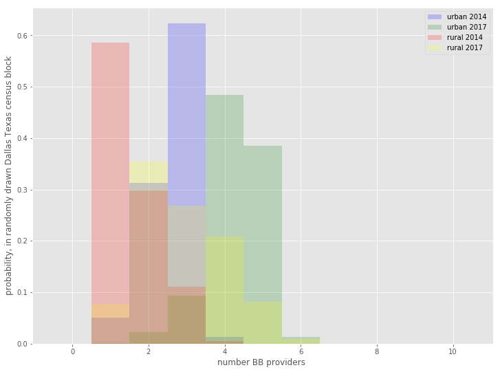

```python
blist=[-.5,.5,1.5,2.5,3.5,4.5,5.5,6.5,7.5,8.5,9.5,10.5]
fig, ax = plt.subplots(figsize=(12,9))
ax.hist(outcomph.sumc14[(outcomph.u_dum==1)],color='blue',alpha=.2,density=True,bins=blist)
ax.hist(outcomph.sumc17[(outcomph.u_dum==1)],color='green',alpha=.2,density=True,bins=blist)
ax.hist(outcomph.sumc14[(outcomph.u_dum==0)],color='red',alpha=.2,density=True,bins=blist)
ax.hist(outcomph.sumc17[(outcomph.u_dum==0)],color='yellow',alpha=.2,density=True,bins=blist)
ax.legend(['urban 2014','urban 2017','rural 2014','rural 2017'])
ax.set_ylabel('probability, in randomly drawn Dallas Texas census block')
ax.set_xlabel('number BB providers ');
```

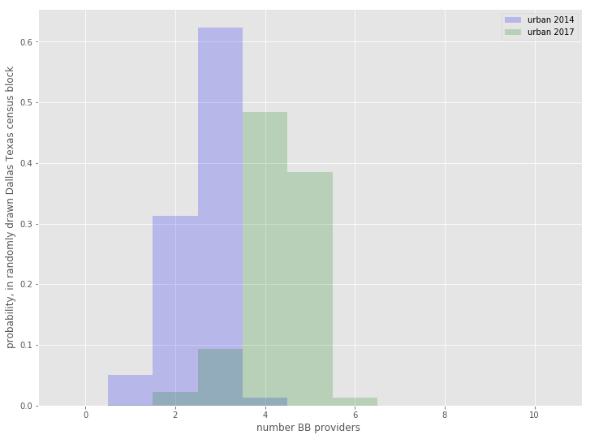

```python
blist=[-.5,.5,1.5,2.5,3.5,4.5,5.5,6.5,7.5,8.5,9.5,10.5]
fig, ax = plt.subplots(figsize=(12,9))
ax.hist(outcomph.sumc14[(outcomph.u_dum==1)],color='blue',alpha=.2,density=True,bins=blist)
ax.hist(outcomph.sumc17[(outcomph.u_dum==1)],color='green',alpha=.2,density=True,bins=blist)

ax.legend(['urban 2014','urban 2017'])
ax.set_ylabel('probability, in randomly drawn Dallas Texas census block')
ax.set_xlabel('number BB providers ');
```

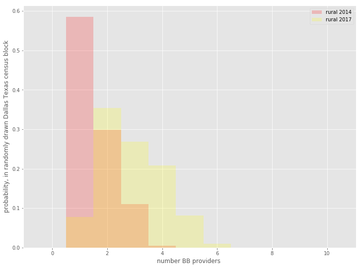

```python
blist=[-.5,.5,1.5,2.5,3.5,4.5,5.5,6.5,7.5,8.5,9.5,10.5]
fig, ax = plt.subplots(figsize=(12,9))

ax.hist(outcomph.sumc14[(outcomph.u_dum==0)],color='red',alpha=.2,density=True,bins=blist)
ax.hist(outcomph.sumc17[(outcomph.u_dum==0)],color='yellow',alpha=.2,density=True,bins=blist)
ax.legend(['rural 2014','rural 2017'])
ax.set_ylabel('probability, in randomly drawn Dallas Texas census block')
ax.set_xlabel('number BB providers ');
```